# Covid-19: Sağlık mı, ekonomi mi?

Erol Taymaz  
İktisat Bölümü, Orta Doğu Teknik Üniversitesi  
http://users.metu.edu.tr/etaymaz

EconTR2020@Eskişehir / 10-12 Eylül 2020

# Covid-19: Sağlık mı, ekonomi mi?

[figure not shown]

# Covid-19: Sağlık mı, ekonomi mi?

[figure not shown]

“President Donald Trump fixed his course on reopening the nation for business, acknowledging that the move would cause more illness and death from the pandemic but insisting it’s a cost he’s willing to pay to get the economy back on track.”

Source: [Bloomberg, 6 Mayıs 2020](https://www.bloomberg.com/news/articles/2020-05-06/trump-pivots-to-phase-two-risking-more-death-to-save-economy)

# Konular

**Covid-19’un etkileri: Sağlık ve ekonomi**

- **Ne olacak(dı)?** Tahminler
  - Politikalar
- **Ne oldu?** Gerçekleşmeler
- **Ne olabilirdi?** Sahte ikilem
- **İktisadi modellerin önemi**

# Ne olacak(dı)? Tahminler

**Covid-19’un ekonomik etkileri**

- **Kısa dönem**
  - Bazı ekonomik faaliyetlerin kısıtlanması
  - Tüketim harcamalarının azalması
  - Belirsizlik ve yatırım harcamalarının azalması
  - Dış talebin düşmesi (ihracat etkisi)
- **Uzun dönem**
  - İnsan sermayesinin aşınması
  - Yatırımların azalması
  - Davranışların değişmesi
  - Yeniliklerin yönünün değişmesi

**Kimler daha çok etkileniyor?**

# Kısa dönem ekonomik etki tahmini

**Girdi-çıktı modeli**

- Sektörler arası etkileşim
- Gelirdeki düşmenin etkisi
  - Kısıtlamalara ilişkin varsayımlar
  - Tüketim ve yatırım harcamalarına ilişkin varsayımlar

**Veri kaynakları**

- 2012 IO tablosu
- 2017 ulusal hesaplar (ana sektörler - katma değer ve tüketim)
- 2017 hane halkı işgücü anketi (ana sektörler - istihdam ve kompozisyonu)
- 2017 sanayi ve hizmet istatistikleri (alt sektörler - istihdam ve katma değer)
- Firma bilanço ve vergi istatistikleri

# Varsayımlar

- Kısıtlanan sektörler (özel tüketim ve ihracat talebi %80 azalıyor)
  - Hava yolu, konaklama ve yiyecek, seyahat-turizm, gösteri ve eğlence, spor ve dinlence
- Tüketim talebi düşecek sektörler (özel tüketim ve ihracat talebi %30 azalıyor)
  - Tekstil ve giyim, petrol, bilgisayar-elektronik, otomobil, mobilya, otomobil ticaret, perakende ticaret, kara taşımacılığı
- Tüketim talebi artacak sektörler
  - Eczacılık (%20), telekom hizmetleri (%20), balık, gıda ve yiyecek (%13)
- Gelir etkisi
  - Her sektörde üretimdeki düşme oranında işgücü talebi düşüyor
  - Ücret ve ücret dışı gelirler aynı oranda azalıyor
    - Gelirlerdeki düşüş, özel tüketimde düşüşe yol açıyor

# Senaryolar

**Senaryolar**

- Senaryo 1: Bazı faaliyetlerin kısıtlanması
- Senaryo 2: Yatırımlarda %20, özel tüketimde %10 düşme
- Senaryo 3: Yatırımlarda %10, özel tüketimde %5 düşme

**Politikalar**

- Politika 1: İşini kaybeden ücretlilere gelir desteği
- Politika 2: Politika 1 + serbest meslek sahipleri ve küçük aile işletmelerine gelir desteği
- Politika 3: Politika 2 + yatırım ortamında %50 düzelme

Tüm politikalar Senaryo 2 için uygulandı

# Politikalar

- **İşten çıkarmanın yasaklanması**
  - Ahlak ve iyi niyet kurallarına uymayan haller, iş veya hizmet sözleşmelerinde sürenin sona ermesi, iş yerinin faaliyetinin sona ermesi, işin sona ermesi halleri dışında, işveren tarafından feshedilmesi yasaklandı.
- **Kısa çalışma ödeneği (KÇÖ)**
  - Genel ekonomik, sektörelveya bölgesel kriz ile zorlayıcı sebeplerle işyerindeki haftalık çalışma sürelerinin geçici olarak önemli ölçüde azaltılması veya işyerinde faaliyetin tamamen veya kısmen geçici olarak durdurulması hallerinde çalışılmayan süreler için çalışanlara kısa çalışma ödeneği ödenmektedir.
- **Zorunlu ücretsiz izin - Nakdi ücret desteği (NÜD)**
  - İş sözleşmesi bulunmakla birlikte işveren tarafından ücretsiz izne ayrılan ve kısa çalışma ödeneğinden yararlanamayan işçiler ile 15/3/2020 tarihinden sonra 51 inci madde kapsamında iş sözleşmesi feshedilen ve bu Kanunun diğer hükümlerine göre işsizlik ödeneğinden yararlanamayan işçilere, herhangi bir sosyal güvenlik kuruluşundan yaşlılık aylığı almamak kaydıyla ücretsiz izinde bulundukları veya işsiz kaldıkları süre kadar, Fondan günlük 39,24 Türk lirası nakdi ücret desteği verilir.

# Tahminler

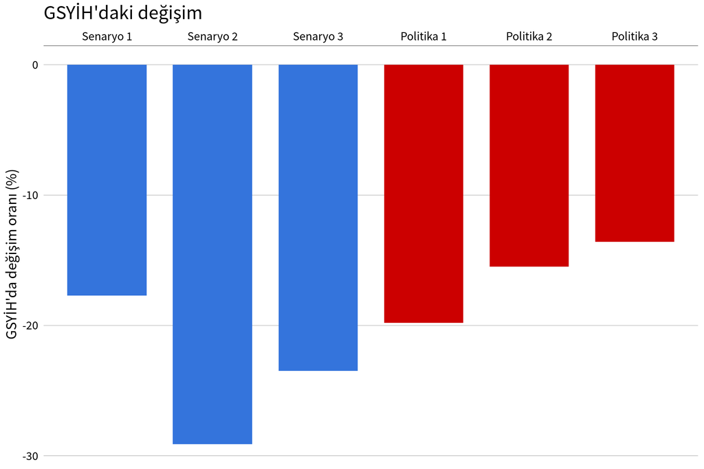

# Tahmin ve gerçekleşmeler

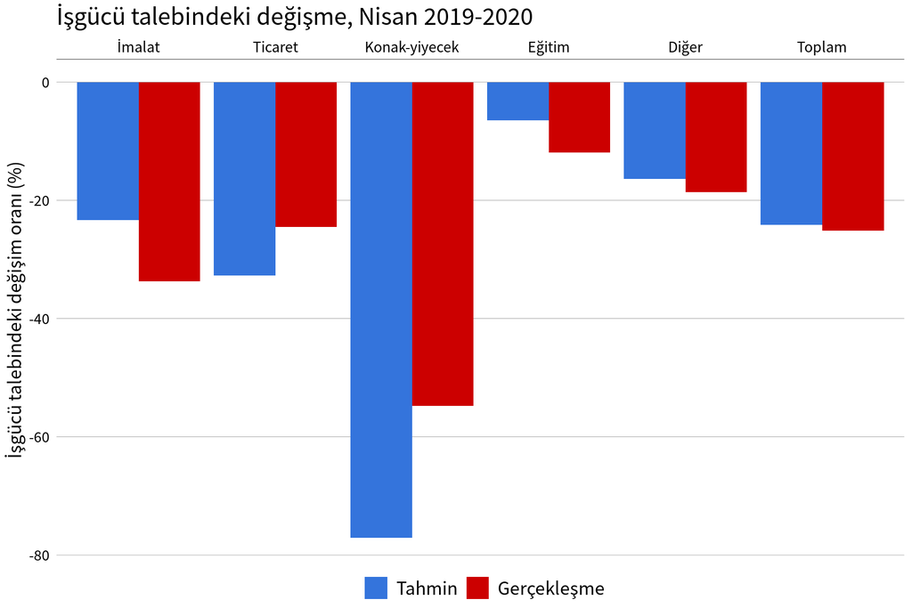

Gerçekleşmeye kısa çalışma ödeneği (KÇÖ) ve nakdi ücret desteği (NÜD) alanların sayısı dahildir.

# Gerçekleşmeler - kayıtdışı istihdam

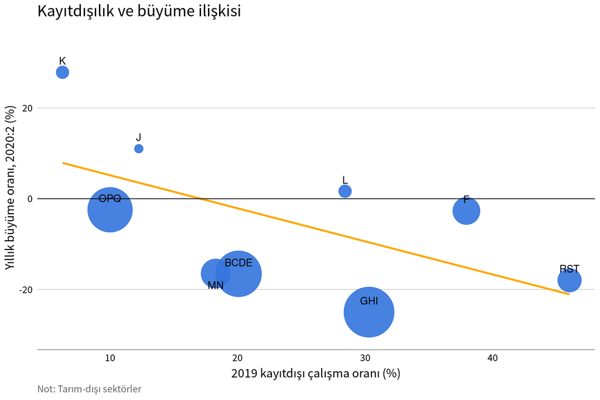

# Gerçekleşmeler - kayıtdışı istihdam

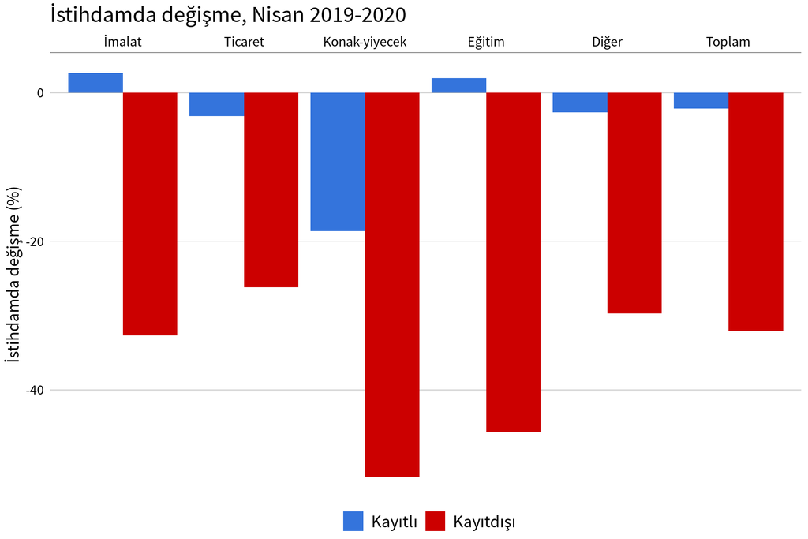

# Gerçekleşmeler - Politika etkisi

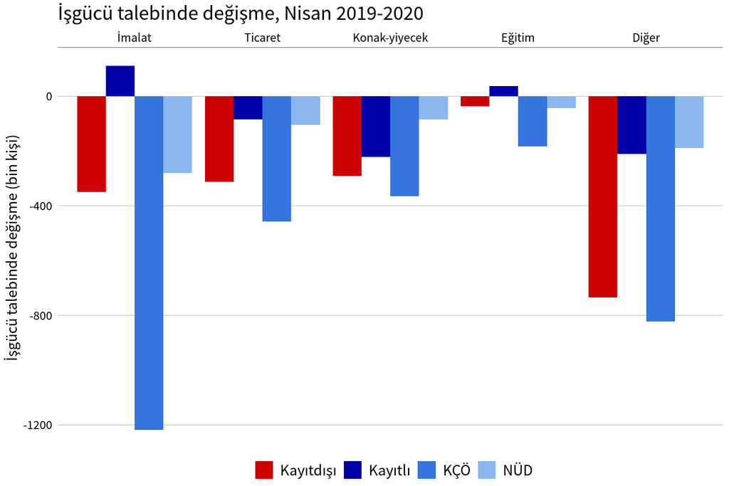

# Gerçekleşmeler

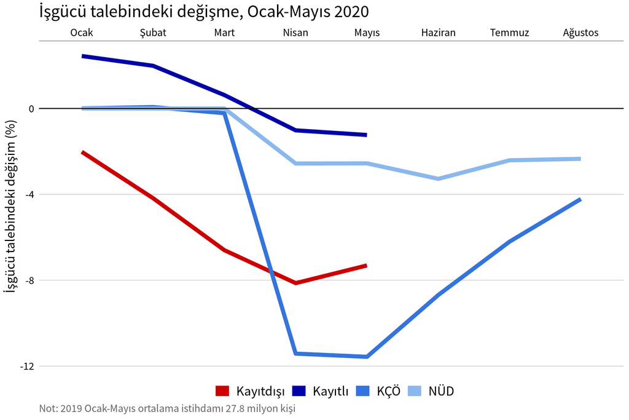

# Covid-19 tedbirleri ve sağlık

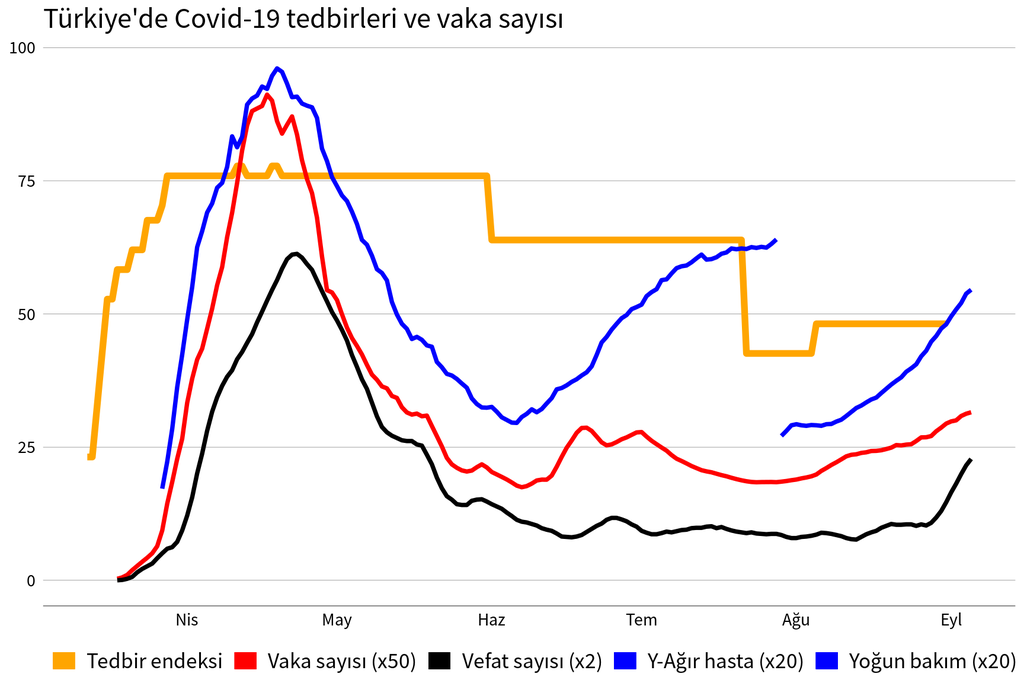

# Covid-19 tedbirleri ve sağlık

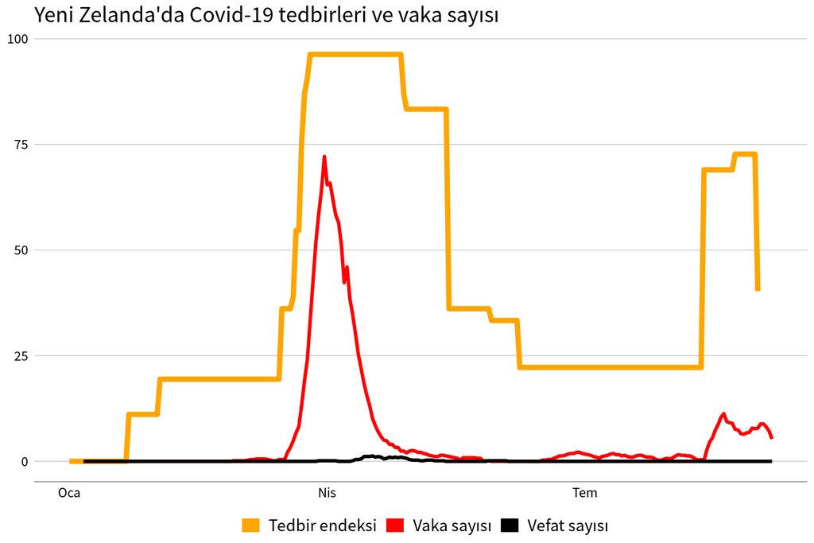

# Mikrosimülasyon modeli

**Model**

- Kişi bazında model
  - Hane, yaş, cinsiyet, okul, sektör, meslek, bölge
- Her kişi bir günün 16 saatini farklı ortamlarda geçiriyor
  - Ev, okul, iş, zorunlu faaliyetler (alış veriş), serbest faaliyetler (eğlence, spor), seyahat
- Covid-19 belirli bir ortamda temas ile bulaşıyor
  - Belirli bir ortamda bulunan sağlıklı ve hasta insan sayısına bağlı olarak bulaşıyor
- Covid-19 bulaşanlar belirli aşamalardan geçerek iyileşiyor veya vefat ediyor

# Mikrosimülasyon modeli

**Tedbirlerin etkisi**

- Zaman kullanımında değişim
- Davranışlarda değişim (maske, mesafe, hijyen)
- Sağlık sisteminde değişim
  - Hastaların yoğun bakımda yatma oranı, yoğun bakımdakilerin vefat oranı
  - Hastaların tespit edilme/karantina süresi

# Simülasyon sonuçları - yoğun bakım hasta sayısı

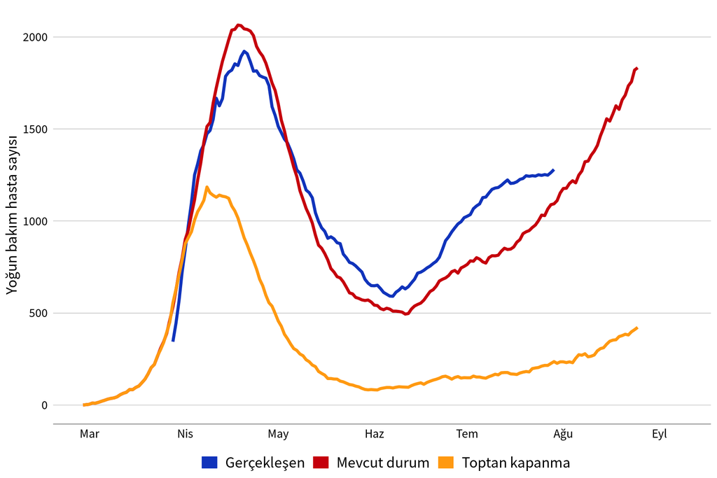

# Simülasyon sonuçları - vefat sayısı

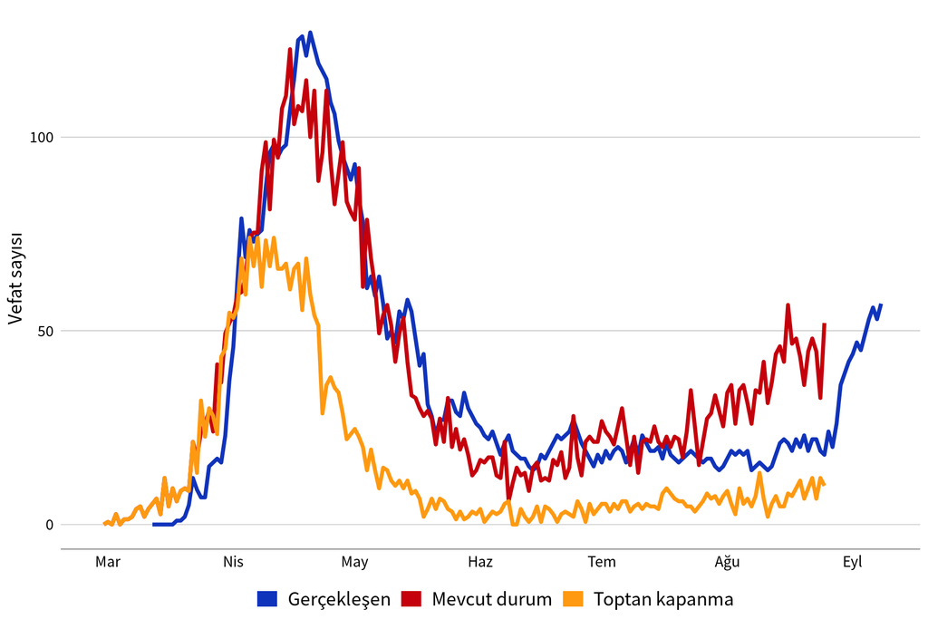

# Simülasyon sonuçları - yeni vaka sayısı

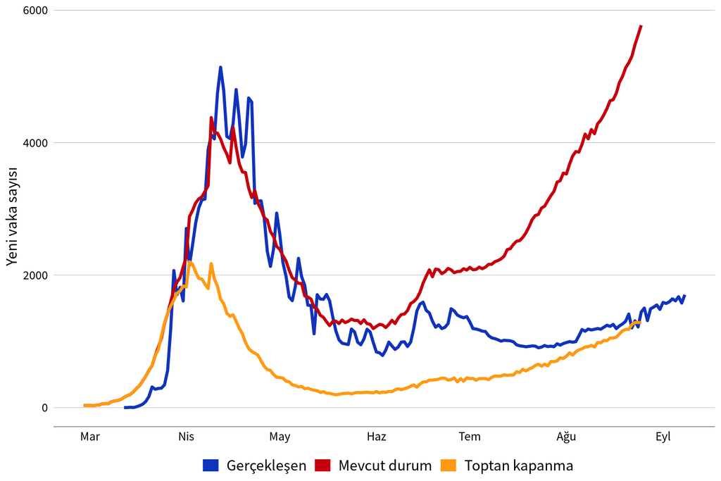

# Sahte ikilem

**Sağlık mı, ekonomi mi?**

- Uzun dönem
  - Sağlık ve ekonomi arasındaki ilişki pozitif
- Kısa dönem
  - Covid-19 örneğinde sağlık ve ekonomi arasındaki ilişki pozitif
  - Sağlık ve ekonomi arasında seçim yapmak durumunda değiliz

**Tedbirler**

- Tam kapanma
  - Vaka sayısını kontrol edilebilir düzeye indirmek gerekli
    - Bölgesel tam kapanma
- Test ve filyasyon
  - Vakaları erken tespit ederek tekrar yaygınlaşmasını engellemek gerekli
- **Sağlık ve ekonomi için hastaları tedavi etmek değil, hastalanmamasını sağlamak gerekli**

# Politika oluşturma

- Modellemenin önemi
- Açık verinin önemi

*Sağlıklı günler dileğiyle…*

**Kaynaklar**

- Erol Taymaz, “Covid-19 tedbirlerinin Türkiye ekonomisine etkisi ve çözüm önerileri”, [Sarkaç](https://sarkac.org/2020/04/covid19-tedbirlerinin-turkiye-ekonomisine-etkisi-cozum-onerileri/), 8 Nisan 2020.
- Erol Taymaz, “Salgın devam ederken ekonomi düzelebilir mi? – Bir mikrosimülasyon analizi”, [Sarkaç](https://sarkac.org/2020/07/salgin-devam-ederken-ekonomi-duzelebilir-mi/), 9 Temmuz 2020.